# STSCI 4630 - Lec 02

Harry Lu

January 24, 2019

Recall: $r_t=\ln\left(\frac{P_t}{P_{t-1}}\right)$

The log-normal model assumes $r_t$s are $i.i.d.$ and $N(\mu,\sigma^2)$

$$r_t(k)=\ln\left(\frac{P_t}{P_{t-k}}\right)=r_{t-k+1}+\cdots+r_{t-1}+r_t$$

under the log-normal model $r_t(k) \sim N(k\mu,k\sigma^2)$

so $1+R_t(k)=e^{r_t(k)} \sim \text{log normal }(k\mu,k\sigma^2)$

$$\begin{align}
P(1+R_t(k) \leq x)
&=
P(r_t(k) \leq \ln(x))\\
&=
\Phi\left(\frac{\ln(x)-k\mu}{\sqrt{k}\cdot\sigma}\right)
\end{align}$$

**Example**

> Suppose $r_t \sim N(0.02,0.2^2)$. What is the 3-period gross return is at most 80%?

$$P(1+R_t(3) \leq 0.8)=\Phi\left(\frac{\ln(0.8)-3\times 0.02}{\sqrt{3}\times 0.2}\right)\approx 20.686\%$$

$$\text{E}(1+R_t(3))=e^{0.06+\frac{3(0.2)^2}{2}}\approx 1.1275$$

$$\text{Var}(1+R_t(3))=(e^{3(0.2)^2}-1)e^{2(0.06)+3(0.2)^2}\approx 0.16208$$

Aside on Random Walks:

$Z_1,Z_2,\cdots$ are $i.i.d.$ with mean $\mu$ and variance $\sigma^2$

Let $S_0$ be an initial starting point

Let $S_t=S_0+Z_1+Z_2+\cdots+Z_t$ where $t=1,2,3,\cdots$

$\{S_t\}_{t=0}^\infty$ is a random walk process

$\{S_t\}_{t=1}^\infty$ is the step process

$$Z_t=
\left\{\begin{array}{l}
+1 & ,\text{w.p. }p\\
-1 & ,\text{w.p. }1-p
\end{array}\right.$$

$$\text{E}(S_t|S_0)=s_0+\mu t$$

$$\text{Var}(S_t|S_0)=\sigma^2t$$

If $Z_t \sim N(\mu,\sigma^2)$, then $\{S_t\}_{t=0}^\infty$ is called a normal random walk

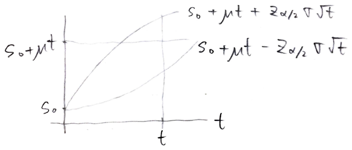

$$P(S_t \in (S_0+\mu t)\pm Z_{\frac{\alpha}{2}}\sigma\sqrt{t}\ |S_0)=1-\alpha$$

$$S_t|S_0 \sim N(S_0+\mu t,\sigma^2t)$$

If $\{S_t\}_{t=0}^\infty$ is a random walk process, then $\{e^{S_t}\}_{t=0}^\infty$ is called a geometric (exponential) random walk

$$e^{S_t}=e^{S_0}\times e^{Z_1}\times\cdots\times e^{Z_t}$$

If $Z_t \sim N(\mu,\sigma^2)$, then $\{e^{S_t}\}_{t=0}^\infty$ is called a log-normal geometric random walk

Connection with log gross return:

recall $\ln\left(\frac{P_t}{P_{t-k}}\right)=r_{t-k+1}+\cdots+r_t=r_t(k)$, where $r_t(k)$ is k-period log gross return

put $k=t$: $\frac{P_t}{P_0}=r_1+\cdots+r_t=r_t(t)$

If $r_1,r_2,\cdots$ are $i.i.d.$ with mean $\mu$ and variance $\sigma^2$, then $r_t(t)=r_1+\cdots+r_t$ is a random walk starting at 0

also, $\ln(P_t)=\ln(P_0)+r_1+\cdots+r_t$ is a random walk starting at $\ln(P_0)$

so $\{P_t\}_{t=0}^\infty$ is a geometric random walk with parameters $\mu$ and $\sigma^2$

$\text{E}(P_t|P_0)=P_0\cdot e^{\mu t+\frac{\sigma^2t}{2}}$, median $(P_t|P_0)=P_0\cdot e^{\mu t}$ since $P_t=P_0\cdot \underbrace{e^{r_1+\cdots+r_t}}_\text{log normal}$

Two Important Questions:

1. Are the returns normally distributed?
2. Are the returns independent?

Normal Probability Plots:

Suppose $X_1,\cdots,X_n$ is a sample from a normal population

Let $X_{(1)},\cdots,X_{(n)}$ be the “order statistics”, smallest to largest

$X_{(i)}$ estimates the $\frac{i}{n+1}$ - quantile of the distribution

If the distribution is normal, then $X_{(i)} \approx \mu+\sigma\cdot\Phi^{-1}\left(\frac{i}{n+1}\right)$, where $\Phi^{-1}\left(\frac{i}{n+1}\right)$ is the quantile of $N(0,1)$ distribution

so if we plot $X_{(i)}$ v.s. $\Phi^{-1}\left(\frac{i}{n+1}\right)$, and if the distribution is normal, the plot should be roughly a straight line

alternatively, plot $X_{(i)}$ v.s. $\text{E}(Z_{(i)})$ where $Z_1,\cdots,Z_n$ is a sample from $N(0,1)$

v.s. $\Phi^{-1}\left(\frac{i-\frac{1}{2}}{n}\right)$

Types of Deviation from Normality: ($X_{(i)}$ v.s. $\Phi^{-1}\left(\frac{i-\frac{1}{2}}{n}\right)$)

1. convex (left-skewed)

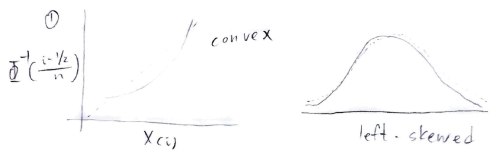

2. concave (right-skewed)

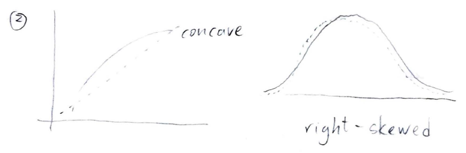

3. convex-concave (heavier-tails than normal)

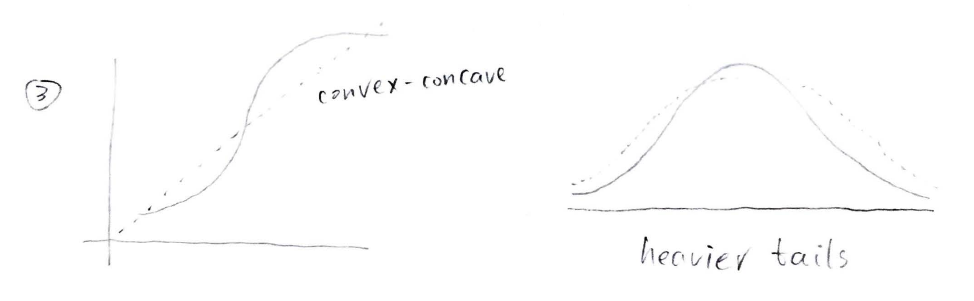

4. concave-convex (lighter-tails than normal)

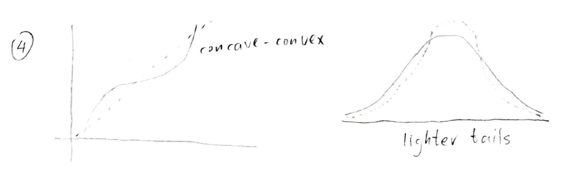

standardized skewness:

$$\text{E}\left[\left(\frac{x-\mu}{\sigma}\right)^3\right]=\text{sk}$$

standardized kurtosis:

$$\text{E}\left[\left(\frac{x-\mu}{\sigma}\right)^4\right]=\text{kur}$$

Jarque-Bera Test:

$$\text{JB}=n\left[\frac{(\hat{\text{sk}})^2}{6}+\frac{(\hat{\text{kur}}-3)^2}{24}\right] \sim \chi^2_2 \quad \text{asymptotically}$$

Thanks to *Zhenjie Shen* for help with the figures.